# 04_Biodiversity

2026-04-16

```r
pacman::p_load(tidyverse, devtools, patchwork, iNEXT, phyloseq, ggpubr, rstatix,
               install = FALSE)

# Load colors and shapes
source("/local/workdir/yz3272/Biodiversity_Salinity_16S/code/colors_and_shapes.R")
source("/local/workdir/yz3272/Biodiversity_Salinity_16S/code/functions.R")

#load data
load("/local/workdir/yz3272/BIOMI6300_IronMicrobiotaProject/03_Pre-processing/preprocessed_phyloseq.RData")
preprocessed_physeq
```

```
## phyloseq-class experiment-level object
## otu_table()   OTU Table:         [ 1591 taxa and 102 samples ]
## sample_data() Sample Data:       [ 102 samples by 3 sample variables ]
## tax_table()   Taxonomy Table:    [ 1591 taxa by 9 taxonomic ranks ]
```

```r
# Intuition check on seq depth
min(sample_sums(preprocessed_physeq))
```

```
## [1] 21454
```

```r
metadata_df <-
  preprocessed_physeq %>%
  sample_data() %>%
  data.frame()
metadata_df
```

```
##              ID Group Iron.intake
## SRR29920099 100   CRC         500
## SRR29920100  99   CRC         500
## SRR29920101  98   CRC         500
## SRR29920102  97   CRC         500
## SRR29920103  96   CRC         500
## SRR29920104  95   CRC         500
## SRR29920105  94   CRC         500
## SRR29920106  93   CRC         500
## SRR29920107  92   CRC         500
## SRR29920108  91   CRC         500
## SRR29920109  10    HC          50
## SRR29920110  90   CRC         500
## SRR29920111  89   CRC         500
## SRR29920112  88   CRC         500
## SRR29920113  87   CRC         500
## SRR29920114  86   CRC         500
## SRR29920115  85   CRC         500
## SRR29920116  84   CRC         500
## SRR29920117  83   CRC         500
## SRR29920118  82   CRC         500
## SRR29920119  81   CRC         500
## SRR29920120   9    HC          50
## SRR29920121  80   CRC         500
## SRR29920122  79   CRC         500
## SRR29920123  78   CRC         500
## SRR29920124  77   CRC         500
## SRR29920125  76   CRC         500
## SRR29920126  75   CRC          50
## SRR29920127  74   CRC          50
## SRR29920128  73   CRC          50
## SRR29920129  72   CRC          50
## SRR29920130  71   CRC          50
## SRR29920131   8    HC          50
## SRR29920132  70   CRC          50
## SRR29920133  69   CRC          50
## SRR29920134  68   CRC          50
## SRR29920135  67   CRC          50
## SRR29920136  66   CRC          50
## SRR29920137  65   CRC          50
```

[output cut: 48 more lines]

```
## SRR29920186   3    HC          50
## SRR29920187  20    HC          50
## SRR29920188  19    HC          50
## SRR29920189  18    HC          50
## SRR29920190  17    HC          50
## SRR29920191  16    HC          50
## SRR29920192  15    HC          50
## SRR29920193  14    HC          50
## SRR29920194  13    HC          50
## SRR29920195  12    HC          50
## SRR29920196 102   CRC         500
## SRR29920197 101   CRC         500
## SRR29920198  11    HC          50
## SRR29920199   2    HC          50
## SRR29920200   1    HC          50
```

```r
# Species in rows, samples in columns
iNEXT_input_df <-
  preprocessed_physeq %>%
  otu_table() %>%
  data.frame()

# Inspect
dim(iNEXT_input_df)
```

```
## [1] 1591  102
```

```r
# Run iNEXT
#iNEXT_data <- iNEXT(
#  iNEXT_input_df,
#  q = c(0, 1, 2),
#  datatype = "abundance")

#save(iNEXT_data, file = "/local/workdir/yz3272/BIOMI6300_IronMicrobiotaProject/04_Biodiversity/iNEXT_data.RData")

load("/local/workdir/yz3272/BIOMI6300_IronMicrobiotaProject/04_Biodiversity/iNEXT_data.RData")

# Inspect
str(iNEXT_data)
```

```
## List of 3
##  $ DataInfo:'data.frame':    102 obs. of  14 variables:
##   ..$ Assemblage: chr [1:102] "SRR29920099" "SRR29920100" "SRR29920101" "SRR29920102" ...
##   ..$ n         : num [1:102] 42560 40601 35469 44925 43217 ...
##   ..$ S.obs     : num [1:102] 67 56 106 92 81 105 160 205 158 195 ...
##   ..$ SC        : num [1:102] 1 1 1 1 1 1 1 1 1 1 ...
##   ..$ f1        : num [1:102] 0 0 1 0 0 0 0 0 1 0 ...
##   ..$ f2        : num [1:102] 1 0 0 2 0 1 1 1 2 1 ...
##   ..$ f3        : num [1:102] 3 4 1 2 2 4 6 6 3 2 ...
##   ..$ f4        : num [1:102] 3 0 4 6 2 3 1 1 3 6 ...
##   ..$ f5        : num [1:102] 1 5 4 1 1 2 5 3 2 3 ...
##   ..$ f6        : num [1:102] 3 2 0 1 2 7 2 5 4 6 ...
##   ..$ f7        : num [1:102] 1 4 3 3 1 3 2 4 3 8 ...
##   ..$ f8        : num [1:102] 2 0 2 6 2 4 3 4 4 8 ...
##   ..$ f9        : num [1:102] 2 2 6 2 3 3 7 3 7 8 ...
##   ..$ f10       : num [1:102] 3 1 3 2 2 2 2 9 6 4 ...
##  $ iNextEst:List of 2
##   ..$ size_based    :'data.frame':   12240 obs. of  10 variables:
##   .. ..$ Assemblage: chr [1:12240] "SRR29920099" "SRR29920099" "SRR29920099" "SRR29920099" ...
##   .. ..$ m         : num [1:12240] 1 2365 4729 7094 9458 ...
##   .. ..$ Method    : chr [1:12240] "Rarefaction" "Rarefaction" "Rarefaction" "Rarefaction" ...
##   .. ..$ Order.q   : num [1:12240] 0 0 0 0 0 0 0 0 0 0 ...
##   .. ..$ qD        : num [1:12240] 1 48.1 55.9 59.7 61.9 ...
##   .. ..$ qD.LCL    : num [1:12240] 1 47.1 54.8 58.4 60.6 ...
##   .. ..$ qD.UCL    : num [1:12240] 1 49 57.1 61 63.3 ...
##   .. ..$ SC        : num [1:12240] 0.475 0.995 0.998 0.999 0.999 ...
##   .. ..$ SC.LCL    : num [1:12240] 0.469 0.995 0.998 0.999 0.999 ...
##   .. ..$ SC.UCL    : num [1:12240] 0.481 0.995 0.998 0.999 0.999 ...
##   ..$ coverage_based:'data.frame':   6006 obs. of  8 variables:
##   .. ..$ Assemblage: chr [1:6006] "SRR29920099" "SRR29920099" "SRR29920099" "SRR29920099" ...
##   .. ..$ SC        : num [1:6006] 0.475 0.995 0.998 0.999 0.999 ...
##   .. ..$ m         : num [1:6006] 1 2365 4729 7094 9458 ...
##   .. ..$ Method    : chr [1:6006] "Rarefaction" "Rarefaction" "Rarefaction" "Rarefaction" ...
##   .. ..$ Order.q   : num [1:6006] 0 0 0 0 0 0 0 0 0 0 ...
##   .. ..$ qD        : num [1:6006] 1 48.1 55.9 59.7 61.9 ...
##   .. ..$ qD.LCL    : num [1:6006] 0.99 46.79 54.48 58.22 60.48 ...
##   .. ..$ qD.UCL    : num [1:6006] 1.01 49.37 57.4 61.2 63.4 ...
##  $ AsyEst  :'data.frame':    306 obs. of  7 variables:
##   ..$ Assemblage: chr [1:306] "SRR29920099" "SRR29920099" "SRR29920099" "SRR29920100" ...
##   ..$ Diversity : chr [1:306] "Species richness" "Shannon diversity" "Simpson diversity" "Species richness" ...
##   ..$ Observed  : num [1:306] 67 4.67 2.1 56 4.91 ...
##   ..$ Estimator : num [1:306] 67 4.67 2.1 56 4.91 ...
##   ..$ s.e.      : num [1:306] 1.5445 0.0389 0.0123 1.0826 0.0409 ...
##   ..$ LCL       : num [1:306] 67 4.6 2.08 56 4.83 ...
##   ..$ UCL       : num [1:306] 70.03 4.75 2.13 58.12 4.99 ...
##  - attr(*, "class")= chr "iNEXT"
```

```r
# Species in rows and pooled Group-Iron categories in columns
  iNEXT_input_df %>%
  colnames() %>%
  data.frame()
```

```
##               .
## 1   SRR29920099
## 2   SRR29920100
## 3   SRR29920101
## 4   SRR29920102
## 5   SRR29920103
## 6   SRR29920104
## 7   SRR29920105
## 8   SRR29920106
## 9   SRR29920107
## 10  SRR29920108
## 11  SRR29920109
## 12  SRR29920110
## 13  SRR29920111
## 14  SRR29920112
```

[output cut: 88 more lines]

```r
group_iron_colors <- c(
  "CRC-500" = "#d95f02",
  "CRC-50"  = "#66c2a5",
  "HC-500"  = "#fc8d62",
  "HC-50"   = "#1b9e77"
)

color_df <-
  iNEXT_input_df %>%
  colnames() %>%
  data.frame()

colnames(color_df)[1] <- "names"

iNEXT_color_df <-
  color_df %>%
  mutate(
    names = gsub("\\.", "-", names),
    names = gsub("^X", "", names)
  ) %>%
  left_join(
    metadata_df %>%
      tibble::rownames_to_column("names") %>%
      mutate(
        names = gsub("\\.", "-", names),
        names = gsub("^X", "", names),
        group_iron = paste(Group, Iron.intake, sep = "-")
      ),
    by = "names"
  ) %>%
  left_join(
    data.frame(
      group_iron = names(group_iron_colors),
      plot_color = unname(group_iron_colors)
    ),
    by = "group_iron"
  )
```

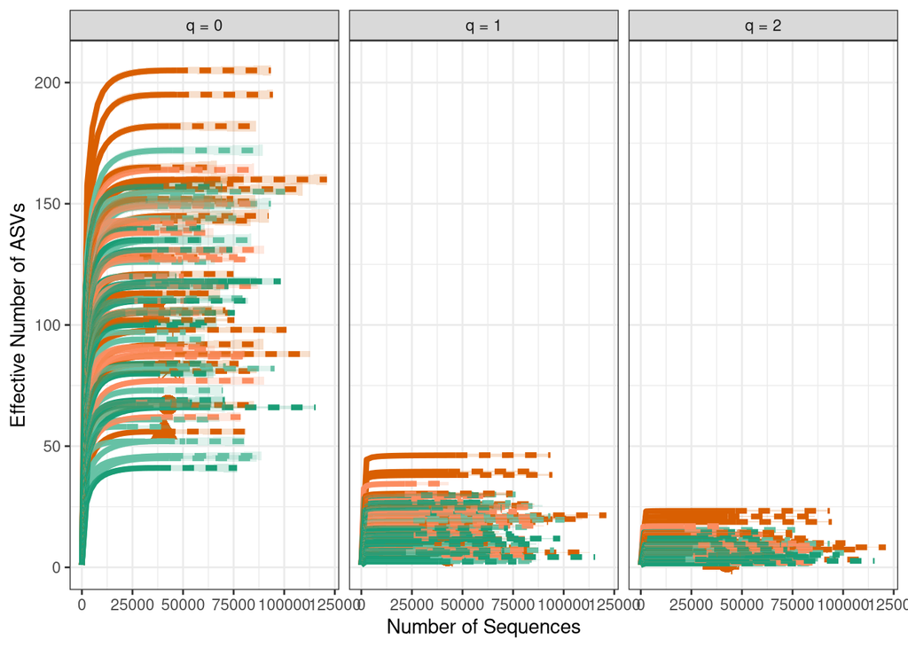

```r
ggiNEXT(iNEXT_data, type = 1, facet.var = "Order.q") +
  scale_color_manual(values = iNEXT_color_df$plot_color) +
  scale_fill_manual(values = iNEXT_color_df$plot_color) +
  theme_bw() +
  theme(legend.position = "none") +
  labs(y = "Effective Number of ASVs", x = "Number of Sequences")
```

```r
str(iNEXT_data)
```

```
## List of 3
##  $ DataInfo:'data.frame':    102 obs. of  14 variables:
##   ..$ Assemblage: chr [1:102] "SRR29920099" "SRR29920100" "SRR29920101" "SRR29920102" ...
##   ..$ n         : num [1:102] 42560 40601 35469 44925 43217 ...
##   ..$ S.obs     : num [1:102] 67 56 106 92 81 105 160 205 158 195 ...
##   ..$ SC        : num [1:102] 1 1 1 1 1 1 1 1 1 1 ...
##   ..$ f1        : num [1:102] 0 0 1 0 0 0 0 0 1 0 ...
##   ..$ f2        : num [1:102] 1 0 0 2 0 1 1 1 2 1 ...
##   ..$ f3        : num [1:102] 3 4 1 2 2 4 6 6 3 2 ...
##   ..$ f4        : num [1:102] 3 0 4 6 2 3 1 1 3 6 ...
##   ..$ f5        : num [1:102] 1 5 4 1 1 2 5 3 2 3 ...
##   ..$ f6        : num [1:102] 3 2 0 1 2 7 2 5 4 6 ...
##   ..$ f7        : num [1:102] 1 4 3 3 1 3 2 4 3 8 ...
##   ..$ f8        : num [1:102] 2 0 2 6 2 4 3 4 4 8 ...
##   ..$ f9        : num [1:102] 2 2 6 2 3 3 7 3 7 8 ...
##   ..$ f10       : num [1:102] 3 1 3 2 2 2 2 9 6 4 ...
##  $ iNextEst:List of 2
##   ..$ size_based    :'data.frame':   12240 obs. of  10 variables:
##   .. ..$ Assemblage: chr [1:12240] "SRR29920099" "SRR29920099" "SRR29920099" "SRR29920099" ...
##   .. ..$ m         : num [1:12240] 1 2365 4729 7094 9458 ...
##   .. ..$ Method    : chr [1:12240] "Rarefaction" "Rarefaction" "Rarefaction" "Rarefaction" ...
##   .. ..$ Order.q   : num [1:12240] 0 0 0 0 0 0 0 0 0 0 ...
##   .. ..$ qD        : num [1:12240] 1 48.1 55.9 59.7 61.9 ...
##   .. ..$ qD.LCL    : num [1:12240] 1 47.1 54.8 58.4 60.6 ...
##   .. ..$ qD.UCL    : num [1:12240] 1 49 57.1 61 63.3 ...
##   .. ..$ SC        : num [1:12240] 0.475 0.995 0.998 0.999 0.999 ...
##   .. ..$ SC.LCL    : num [1:12240] 0.469 0.995 0.998 0.999 0.999 ...
##   .. ..$ SC.UCL    : num [1:12240] 0.481 0.995 0.998 0.999 0.999 ...
##   ..$ coverage_based:'data.frame':   6006 obs. of  8 variables:
##   .. ..$ Assemblage: chr [1:6006] "SRR29920099" "SRR29920099" "SRR29920099" "SRR29920099" ...
##   .. ..$ SC        : num [1:6006] 0.475 0.995 0.998 0.999 0.999 ...
##   .. ..$ m         : num [1:6006] 1 2365 4729 7094 9458 ...
##   .. ..$ Method    : chr [1:6006] "Rarefaction" "Rarefaction" "Rarefaction" "Rarefaction" ...
##   .. ..$ Order.q   : num [1:6006] 0 0 0 0 0 0 0 0 0 0 ...
##   .. ..$ qD        : num [1:6006] 1 48.1 55.9 59.7 61.9 ...
##   .. ..$ qD.LCL    : num [1:6006] 0.99 46.79 54.48 58.22 60.48 ...
##   .. ..$ qD.UCL    : num [1:6006] 1.01 49.37 57.4 61.2 63.4 ...
##  $ AsyEst  :'data.frame':    306 obs. of  7 variables:
##   ..$ Assemblage: chr [1:306] "SRR29920099" "SRR29920099" "SRR29920099" "SRR29920100" ...
##   ..$ Diversity : chr [1:306] "Species richness" "Shannon diversity" "Simpson diversity" "Species richness" ...
##   ..$ Observed  : num [1:306] 67 4.67 2.1 56 4.91 ...
##   ..$ Estimator : num [1:306] 67 4.67 2.1 56 4.91 ...
##   ..$ s.e.      : num [1:306] 1.5445 0.0389 0.0123 1.0826 0.0409 ...
##   ..$ LCL       : num [1:306] 67 4.6 2.08 56 4.83 ...
##   ..$ UCL       : num [1:306] 70.03 4.75 2.13 58.12 4.99 ...
##  - attr(*, "class")= chr "iNEXT"
```

```r
iNEXT_manual_df <-
  iNEXT_data$iNextEst$size_based %>%
  dplyr::rename(names = Assemblage) %>%
  mutate(
    names = gsub("\\.", "-", names),
    names = gsub("^X", "", names)
  ) %>%
  left_join(
    metadata_df %>%
      tibble::rownames_to_column("names") %>%
      mutate(
        names = gsub("\\.", "-", names),
        names = gsub("^X", "", names),
        group_iron = paste(Group, Iron.intake, sep = "-")
      ),
    by = "names"
  )

dim(iNEXT_manual_df)
```

```
## [1] 12240    14
```

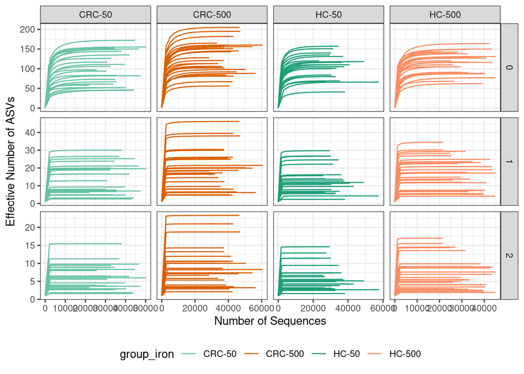

```r
iNEXT_manual_df %>%
  dplyr::filter(Method == "Rarefaction") %>%
  ggplot(aes(x = m, y = qD, color = group_iron, group = names)) +
  geom_line() +
  facet_grid(Order.q ~ group_iron, scales = "free") +
  scale_color_manual(values = group_iron_colors) +
  theme_bw() +
  labs(y = "Effective Number of ASVs", x = "Number of Sequences") +
  theme(legend.position = "bottom")
```

### INTERPRETATION 1:

Both the ggiNEXT and manual rarefaction plots indicate that the sequencing depth here was sufficient. As both figures have most curves rise rapidly at low sequencing depth and then level off, suggesting that samples were sequenced deeply enough to characterize the ASVs. In general, I think it’s valid to make conclusions about richness at q=0, q=1, and q=2, although the platueing is more prominant in q=1 and q=2, while in richness along q=0, mild uptrend reamin observed.

Until this point, I processed all the data in this study. However, starting from alpha diversity, i will only focus on the healthy control mice with 2 iron intake groups, just due to the fact I am only interested in the healthy mice, and do not wish to reproduce their data completely.

```r
#create a seperate df for healthy mice only
alpha_df <-
  iNEXT_data$AsyEst %>%
  dplyr::rename(names = Assemblage) %>%
  mutate(
    names = gsub("\\.", "-", names),
    names = gsub("^X", "", names)
  ) %>%
  left_join(
    metadata_df %>%
      tibble::rownames_to_column("names") %>%
      mutate(
        names = gsub("\\.", "-", names),
        names = gsub("^X", "", names)
      ),
    by = "names"
  )

healthy_df <- alpha_df %>%
  dplyr::filter(Group == "HC", Diversity == "Species richness")

healthy_shannon_df <- alpha_df %>%
  dplyr::filter(Group == "HC", Diversity == "Shannon diversity")

healthy_simpson_df <- alpha_df %>%
  dplyr::filter(Group == "HC", Diversity == "Simpson diversity")

# Normality tests
shapiro.test(as.numeric(healthy_df$Observed[healthy_df$Iron.intake == 50]))
```

```
##
##  Shapiro-Wilk normality test
##
## data:  as.numeric(healthy_df$Observed[healthy_df$Iron.intake == 50])
## W = 0.97257, p-value = 0.7305
```

```r
shapiro.test(as.numeric(healthy_df$Observed[healthy_df$Iron.intake == 500]))
```

```
##
##  Shapiro-Wilk normality test
##
## data:  as.numeric(healthy_df$Observed[healthy_df$Iron.intake == 500])
## W = 0.96662, p-value = 0.538
```

```r
shapiro.test(as.numeric(healthy_shannon_df$Observed[healthy_shannon_df$Iron.intake == 50]))
```

```
##
##  Shapiro-Wilk normality test
##
## data:  as.numeric(healthy_shannon_df$Observed[healthy_shannon_df$Iron.intake == 50])
## W = 0.90437, p-value = 0.02667
```

```r
shapiro.test(as.numeric(healthy_shannon_df$Observed[healthy_shannon_df$Iron.intake == 500]))
```

```
##
##  Shapiro-Wilk normality test
##
## data:  as.numeric(healthy_shannon_df$Observed[healthy_shannon_df$Iron.intake == 500])
## W = 0.94364, p-value = 0.164
```

```r
shapiro.test(as.numeric(healthy_simpson_df$Observed[healthy_simpson_df$Iron.intake == 50]))
```

```
##
##  Shapiro-Wilk normality test
##
## data:  as.numeric(healthy_simpson_df$Observed[healthy_simpson_df$Iron.intake == 50])
## W = 0.87991, p-value = 0.008276
```

```r
shapiro.test(as.numeric(healthy_simpson_df$Observed[healthy_simpson_df$Iron.intake == 500]))
```

```
##
##  Shapiro-Wilk normality test
##
## data:  as.numeric(healthy_simpson_df$Observed[healthy_simpson_df$Iron.intake == 500])
## W = 0.9058, p-value = 0.02115
```

```r
# t-tests
ttest_richness <- healthy_df %>%
  t_test(Observed ~ Iron.intake) %>%
  add_y_position(fun = "max")

ttest_shannon <- healthy_shannon_df %>%
  wilcox_test(Observed ~ Iron.intake) %>%
  add_y_position(fun = "max")

ttest_simpson <- healthy_simpson_df %>%
  wilcox_test(Observed ~ Iron.intake) %>%
  add_y_position(fun = "max")

# View results
ttest_richness
```

```
## # A tibble: 1 × 10
##   .y.      group1 group2    n1    n2 statistic    df     p y.position groups
##   <chr>    <chr>  <chr>  <int> <int>     <dbl> <dbl> <dbl>      <dbl> <named li>
## 1 Observed 50     500       24    26     -1.41  46.8 0.165       165. <chr [2]>
```

```r
ttest_shannon
```

```
## # A tibble: 1 × 9
##   .y.      group1 group2    n1    n2 statistic     p y.position groups
##   <chr>    <chr>  <chr>  <int> <int>     <dbl> <dbl>      <dbl> <named list>
## 1 Observed 50     500       24    26       232 0.123       35.1 <chr [2]>
```

```r
ttest_simpson
```

```
## # A tibble: 1 × 9
##   .y.      group1 group2    n1    n2 statistic     p y.position groups
##   <chr>    <chr>  <chr>  <int> <int>     <dbl> <dbl>      <dbl> <named list>
## 1 Observed 50     500       24    26       248  0.22       17.3 <chr [2]>
```

### The diversity in groups are not all normal, richeness is normal, use t.test. Shannon and simpson are not normal and will use wilcox.test instead of t_test.

```r
### Alpha diversity: Healthy mice only (50 vs 500 iron)

# Species richness only
healthy_df <- alpha_df %>%
  dplyr::filter(Group == "HC", Diversity == "Species richness")

# Welch two-sample t-test
ttest_iron <- healthy_df %>%
  t_test(Observed ~ Iron.intake) %>%
  add_y_position(fun = "max")

ttest_iron
```

```
## # A tibble: 1 × 10
##   .y.      group1 group2    n1    n2 statistic    df     p y.position groups
##   <chr>    <chr>  <chr>  <int> <int>     <dbl> <dbl> <dbl>      <dbl> <named li>
## 1 Observed 50     500       24    26     -1.41  46.8 0.165       165. <chr [2]>
```

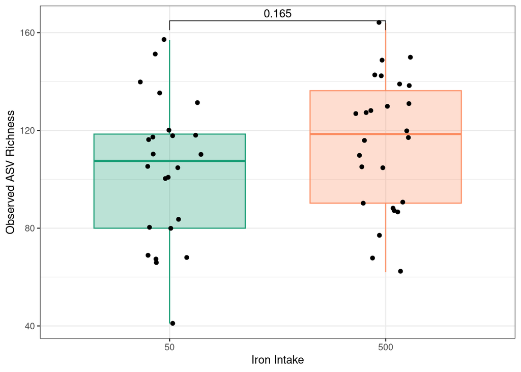

```r
# Boxplot
iron_ggboxplot <-
ggboxplot(
  healthy_df,
  x = "Iron.intake",
  y = "Observed",
  color = "Iron.intake",
  fill = "Iron.intake",
  alpha = 0.3,
  outlier.shape = NA
) +
geom_jitter(width = 0.15) +
stat_pvalue_manual(ttest_iron, label = "p") +
scale_color_manual(values = c("50" = "#1b9e77", "500" = "#fc8d62")) +
scale_fill_manual(values = c("50" = "#1b9e77", "500" = "#fc8d62")) +
labs(
  y = "Observed ASV Richness",
  x = "Iron Intake"
) +
theme_bw() +
theme(legend.position = "none")

iron_ggboxplot
```

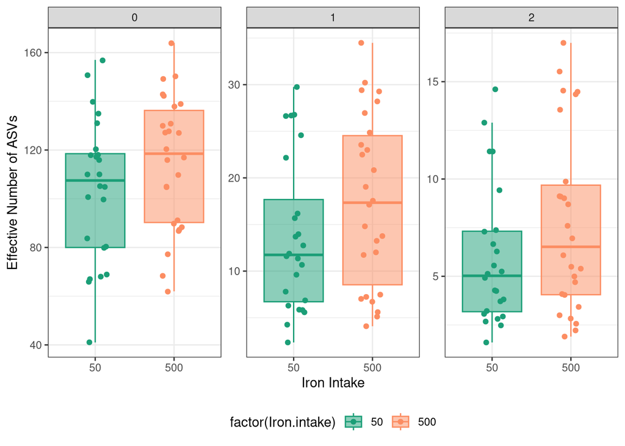

```r
alpha_plot_df <- alpha_df %>%
  dplyr::filter(Group == "HC") %>%
  dplyr::mutate(
    Order.q = dplyr::case_when(
      Diversity == "Species richness"  ~ "0",
      Diversity == "Shannon diversity" ~ "1",
      Diversity == "Simpson diversity" ~ "2"
    )
  )

alpha_plot_df %>%
  ggplot(aes(x = factor(Iron.intake), y = Observed,
             fill = factor(Iron.intake),
             color = factor(Iron.intake))) +
  facet_wrap(. ~ Order.q, scales = "free_y") +
  geom_jitter(width = 0.15) +
  geom_boxplot(alpha = 0.5, outlier.shape = NA) +
  scale_color_manual(values = c("50" = "#1b9e77", "500" = "#fc8d62")) +
  scale_fill_manual(values = c("50" = "#1b9e77", "500" = "#fc8d62")) +
  labs(y = "Effective Number of ASVs", x = "Iron Intake") +
  theme_bw() +
  theme(legend.position = "bottom")
```

###INTERPRETATION 2: If you have categorical data, what can you conclude regarding the role that all ASVs (richess, q = 0) versus common ASVs (Shannon, q = 1) versus dominant ASVs (Simpson, q = 2) have on the biodiversity of your samples as it relates to your variable of interest? For q = 0, the high iron group appeared to have a higher median observed ASV richness than the 50 iron group; however, the difference was not statistically significant, as shown in the previous boxplot (p=0.165). For q = 1 and q = 2, similar visual shifts may suggest changes in common or dominant taxa, but conclusions should depend on their corresponding statistical tests rather than visual inspection alone. Overall, while higher iron intake may show a trend toward increased diversity, none of the alpha diversity test reached statistical significance. Thus, we accept the null hypothesis that the high iron and low iron intake did not alter the gut microbiota in healthy mice.

###INTERPRETATION 3: How did you statistically test your scientific question in Interpretation #2? Why? I used t test for richeness, and then Wilcoxon rank-sum test for simpson and shannon because the diervsity for richeness in groups was normal, but in simpson and shannon indices were not normally distritbuted. Considering i only have 2 test groups to compare for diff, I used parameter and non-parametric t test accrodingly.

```r
# Take the time now that we are at the end of the script
end_time <- Sys.time()
end_time
```

```
## [1] "2026-04-17 22:02:24 EDT"
```

```r
# Echo the elapsed time
elapsed_time <- round((end_time - start_time), 3)
elapsed_time
```

```
## Time difference of 11.324 secs
```